# Walmart Sales Analysis and Forcast

### Voting Regressor

```python
lgbm_params = {'n_estimators': 3500,
               'max_depth':  -1,
               'subsample': 1.0,
               'colsample_bytree': 1.0,
              'n_jobs': -1}

rf_reg_params = {"max_depth": None,
                 "n_estimators": 300,
              'n_jobs': -1}

rf_reg_vot = RandomForestRegressor(**rf_reg_params)
lgbm_vot = LGBMRegressor(**lgbm_params)
```

```python
voter = VotingRegressor([('rf_reg', rf_reg_vot), ('lgmb', lgbm_vot)])
voter.fit(X_train_feat_sc, y_train)
```

```
{'mae_train': 849.2583144338224,
 'r2_train': 0.9940703866315306,
 'mae_test': 2043.2124756524986,
 'r2_test': 0.9653375919410654}
```

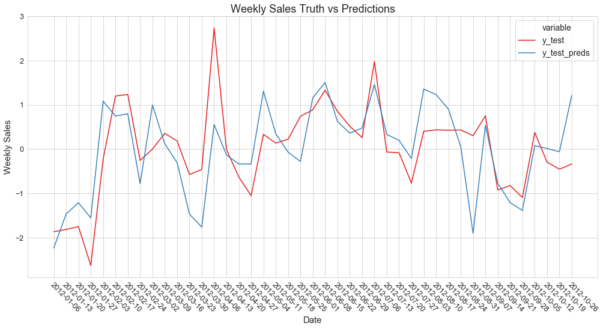

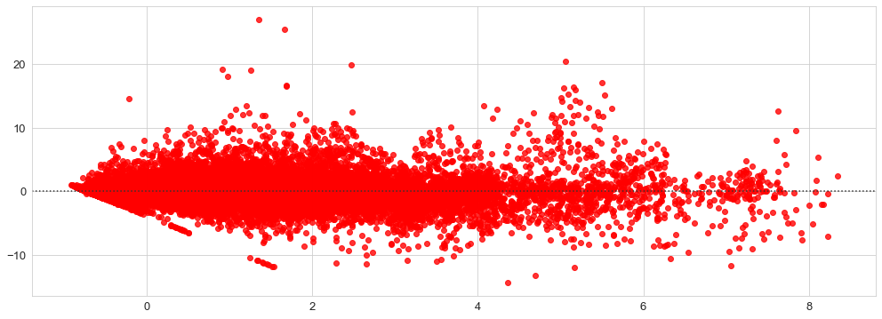

```python
y_train_preds = voter.predict(X_train_feat_sc)
y_test_preds = voter.predict(X_test_feat_sc)

voter_res = evaluate(indicies, y_train, y_train_preds, y_test, y_test_preds)
voter_res
```

### UMAP Reduced Features Training

```python
voter_umap = VotingRegressor([('rf_reg', rf_reg_vot), ('lgmb', lgbm_vot)])
voter_umap.fit(embedding_train, y_train)
```

```
{'mae_train': 605.0580832268421,
 'r2_train': 0.9871013695932852,
 'mae_test': 12565.775892471815,
 'r2_test': -0.07281590708976471}
```

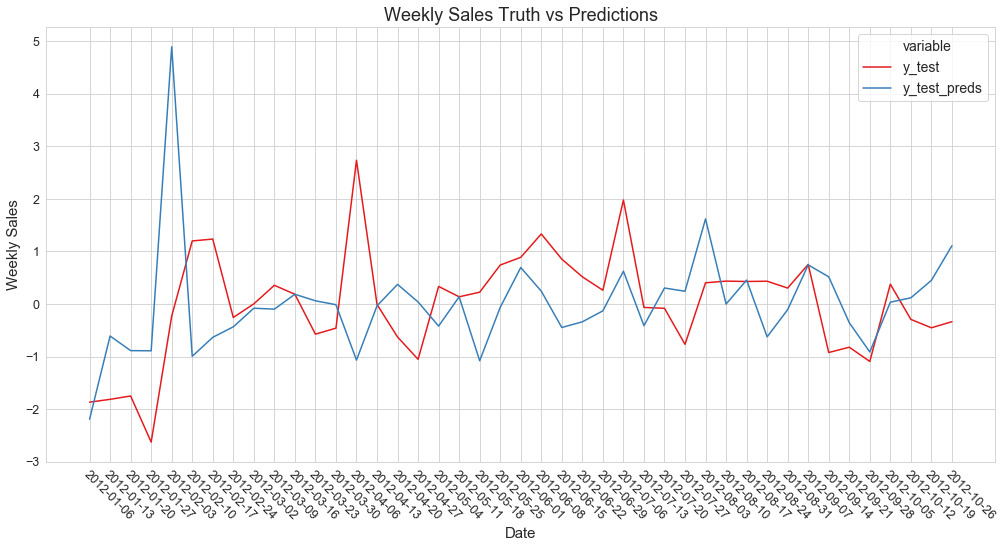

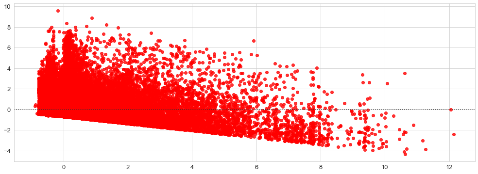

```python
y_train_preds = voter_umap.predict(embedding_train)
y_test_preds = voter_umap.predict(embedding_test)

voter_umap_res = evaluate(indicies, y_train, y_train_preds, y_test, y_test_preds)
voter_umap_res
```

# Quality Metric Summary

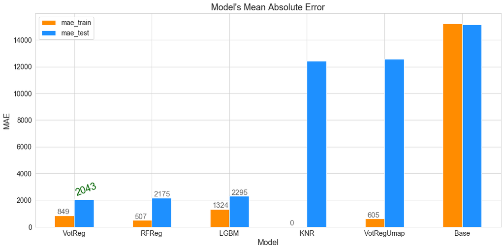

```python
ax = pd.DataFrame([rf_reg_grid_res,lgbm_grid_res, knr_grid_res, voter_res, base_line_grid_res, voter_umap_res] ,
             index=["RFReg", "LGBM", "KNR", "VotReg", "Base", "VotRegUmap"]).sort_values(by=['mae_test'])[["mae_train", "mae_test"]]\
            .plot(kind='bar', figsize=(17,8), color=['darkorange', 'dodgerblue']);
ax.set_xlabel("Model", fontsize=16)
ax.set_ylabel("MAE", fontsize=16)
ax.set_title('Model\'s Mean Absolute Error', fontsize=18);
ax.tick_params(labelsize=14)
plt.setp(ax.xaxis.get_majorticklabels(), rotation=0, rotation_mode="anchor");

counter = 0
for i in ax.patches:
    counter+=1
    if(counter == 1 or counter == 2 or counter == 3 or
         counter == 8 or counter == 9 or counter == 5 or counter == 4):
        ax.text(i.get_x()+ .03, i.get_height()+100, \
            str(int((i.get_height()))), fontsize=15,
                color='dimgray')
    elif(counter == 7):
        ax.text(i.get_x(), i.get_height()+300, \
            str(int((i.get_height()))), fontsize=20,
                color='darkgreen', rotation=20)
```

```
		VotRegUmap and Base were excluded from the graph due to low values. Refer to them in thier healines
```

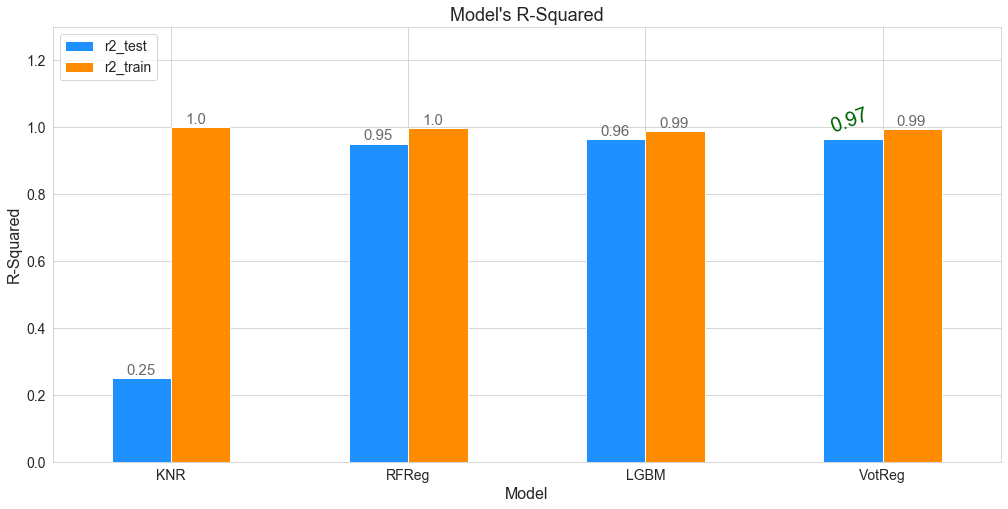

```python
ax = pd.DataFrame([rf_reg_grid_res,lgbm_grid_res, knr_grid_res, voter_res] ,
             index=["RFReg", "LGBM", "KNR", "VotReg"]).sort_values(by=['r2_test'])[["r2_test", "r2_train"]]\
            .plot(kind='bar', figsize=(17,8),colors=['dodgerblue', 'darkorange']);
ax.set_xlabel("Model", fontsize=16)
ax.set_ylabel("R-Squared", fontsize=16)
ax.set_title('Model\'s R-Squared', fontsize=18);
ax.tick_params(labelsize=14)
plt.setp(ax.xaxis.get_majorticklabels(), rotation=0, rotation_mode="anchor");
ax.legend(loc='upper left')
counter = 0
ax.set_ylim(0, 1.3)
for i in ax.patches:
    counter+=1
    if(counter == 4):
        ax.text(i.get_x() + .02, i.get_height()+ 0.02, \
            str(round((i.get_height()), 2)), fontsize=20,
                color='darkgreen', rotation=20)

    else:
        ax.text(i.get_x()+ .06, i.get_height() + 0.01, \
            str(round((i.get_height()), 2)), fontsize=15,
                color='dimgray')

print("\n\n\t\tVotRegUmap and Base were excluded from the graph due to low values. Refer to them in thier healines")
```

# Final Notes

1. KNR is always overfitting on values less than 500. Of course if I had more memory on my machine, I would've gone for more than $\sqrt{n}$ But my machine's memory cannot hold.
2. We can clearly see that has averged between RF Regressor and LGBM models and got a middle ground on the training set but then achieved the highest on the test set
3. Keep in mind that MAE, MSE, RMSE are used for two reasons, a comparison between other models, as well as an indicator of the model's quality in hand. Now, the second can be tricky, the value of MAE depends on the business, environment, and the relative dataset distribution and descriptive statistics. To explain the last one with a very loose example: if **0 < Weekly Sales < 1,000** range of values, an MAE of 10 is similar to 1000 if **0 < Weekly Sales < 100,000**. This is a weak example as of course you need to think about the mean, std., and distributional curve
4. Some of the lower performance achieving models have a very well meaningful residual plot which illustrate a clear trend in errors, this is why we use risedual plots with $R^2$ measurement. In order not to be fooled by $R^2$